# R Notebook

```r
#setwd("~/R_KSU/ML/Assignment 3")
bank <- read.csv("UniversalBank.csv")
```

### Importing libraries

```r
library(dplyr)
library(reshape)
library(reshape2)
library(ggplot2)
library(caret)
```

### Exploratory Data Analysis

```r
str(bank)
```

```
## 'data.frame':    5000 obs. of  14 variables:
##  $ ID                : int  1 2 3 4 5 6 7 8 9 10 ...
##  $ Age               : int  25 45 39 35 35 37 53 50 35 34 ...
##  $ Experience        : int  1 19 15 9 8 13 27 24 10 9 ...
##  $ Income            : int  49 34 11 100 45 29 72 22 81 180 ...
##  $ ZIP.Code          : int  91107 90089 94720 94112 91330 92121 91711 93943 90089 93023 ...
##  $ Family            : int  4 3 1 1 4 4 2 1 3 1 ...
##  $ CCAvg             : num  1.6 1.5 1 2.7 1 0.4 1.5 0.3 0.6 8.9 ...
##  $ Education         : int  1 1 1 2 2 2 2 3 2 3 ...
##  $ Mortgage          : int  0 0 0 0 0 155 0 0 104 0 ...
##  $ Personal.Loan     : int  0 0 0 0 0 0 0 0 0 1 ...
##  $ Securities.Account: int  1 1 0 0 0 0 0 0 0 0 ...
##  $ CD.Account        : int  0 0 0 0 0 0 0 0 0 0 ...
##  $ Online            : int  0 0 0 0 0 1 1 0 1 0 ...
##  $ CreditCard        : int  0 0 0 0 1 0 0 1 0 0 ...
```

> From the above data table stucture we found that - ‘Online’, ‘CreditCard’ & ‘Personal.Loan’ columns have integer data type. But, these are nominal data and we need to convert them to categorical data.

```r
bank$Personal.Loan = as.factor(bank$Personal.Loan)
bank$Online = as.factor(bank$Online)
bank$CreditCard = as.factor(bank$CreditCard)
```

#### Summary statistics of categorical variables.

```r
summary(bank %>% select(Online, CreditCard, Personal.Loan))
```

```
##  Online   CreditCard Personal.Loan
##  0:2016   0:3530     0:4520
##  1:2984   1:1470     1: 480
```

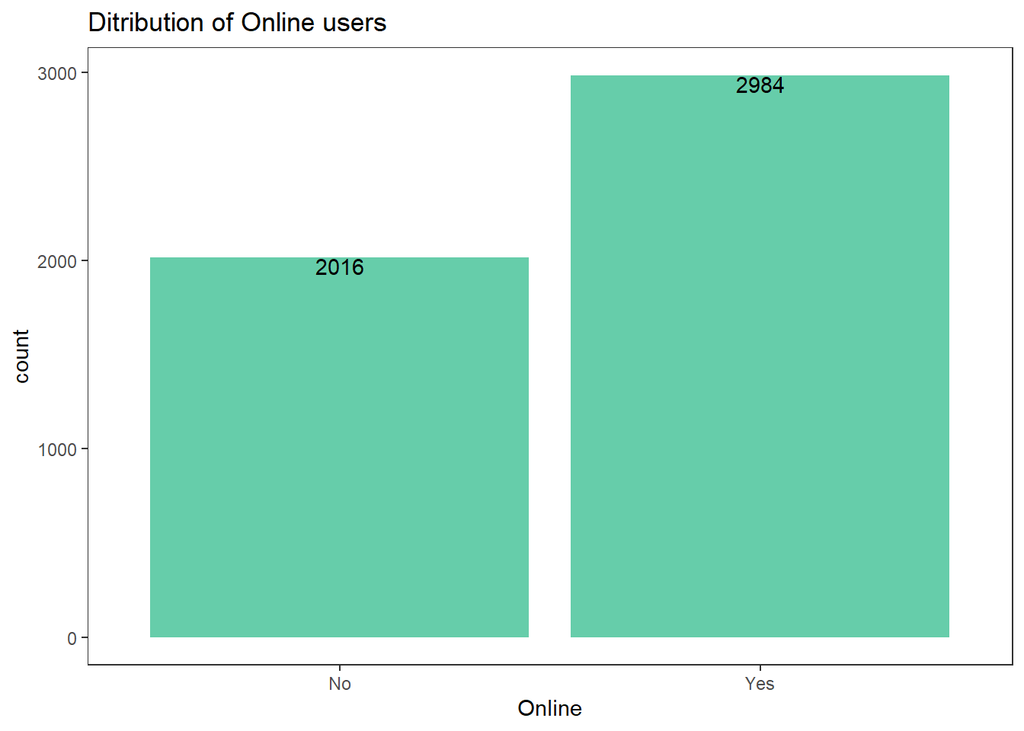

```r
ggplot(bank, aes(x=Online)) + geom_bar( fill='mediumaquamarine') + ggtitle('Ditribution of Online users') + theme_test() + scale_x_discrete(labels=c("No", "Yes")) + geom_text(aes(label=..count..),stat="count", vjust=1)
```

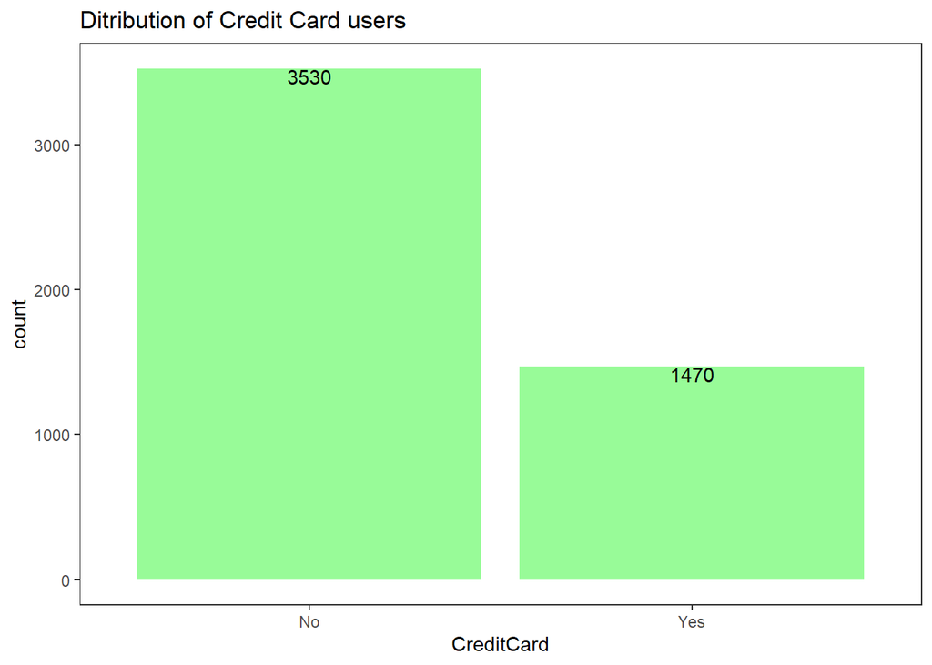

```r
ggplot(bank, aes(x=CreditCard)) + geom_bar( fill='palegreen') + ggtitle('Ditribution of Credit Card users') + theme_test() + scale_x_discrete(labels=c("No", "Yes")) + geom_text(aes(label=..count..),stat="count", vjust=1)
```

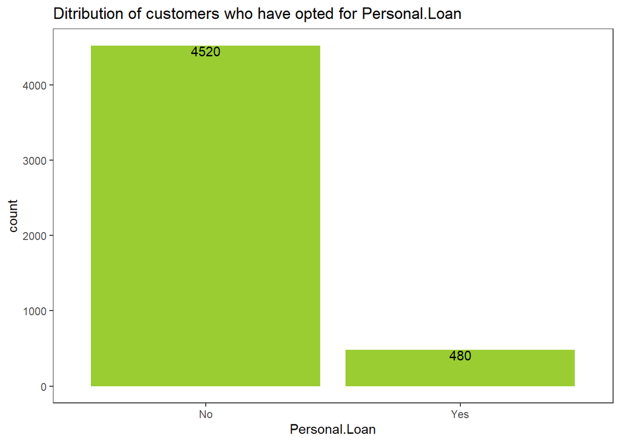

```r
ggplot(bank, aes(x=Personal.Loan)) + geom_bar( fill='olivedrab3') + ggtitle('Ditribution of customers who have opted for Personal.Loan') + theme_test() + scale_x_discrete(labels=c("No", "Yes")) + scale_x_discrete(labels=c("No", "Yes")) + geom_text(aes(label=..count..),stat="count", vjust=1)
```

## Data Preprocessing

> Splitting data into train & test (60-40).

```r
set.seed(1)
train.index <- createDataPartition(bank$Personal.Loan, p=0.6, list= FALSE)
train <- bank[train.index,]
test <- bank[-train.index,]
```

> A. Create a pivot table for the training data with Online as a column variable, CC as a row variable, and Loan as a secondary row variable. The values inside the table should convey the count. In R use functions melt() and cast(), or function table(). In Python, use panda dataframe methods melt() and pivot().

```r
t1= melt(train,id=c('CreditCard','Personal.Loan'),variable='Online')
t1= dcast(t1, CreditCard+Personal.Loan~Online)
t1
```

| CreditCard | Personal.Loan | ID | Age | Experience | Income | ZIP.Code | Family | CCAvg | Education | Mortgage | Securities.Account | CD.Account | Online |
| --- | --- | --- | --- | --- | --- | --- | --- | --- | --- | --- | --- | --- | --- |
| 0 | 0 | 1906 | 1906 | 1906 | 1906 | 1906 | 1906 | 1906 | 1906 | 1906 | 1906 | 1906 | 1906 |
| 0 | 1 | 197 | 197 | 197 | 197 | 197 | 197 | 197 | 197 | 197 | 197 | 197 | 197 |
| 1 | 0 | 806 | 806 | 806 | 806 | 806 | 806 | 806 | 806 | 806 | 806 | 806 | 806 |
| 1 | 1 | 91 | 91 | 91 | 91 | 91 | 91 | 91 | 91 | 91 | 91 | 91 | 91 |

> B. Consider the task of classifying a customer who owns a bank credit card and is actively using online banking services. Looking at the pivot table, what is the probability that this customer will accept the loan offer? [This is the probability of loan acceptance (Loan = 1) conditional on having a bank credit card (CC = 1) and being an active user of online banking services (Online = 1)].

> C. Create two separate pivot tables for the training data. One will have Loan (rows) as a function of Online (columns) and the other will have Loan (rows) as a function of CC.

```r
as.data.frame(table(train[,c('Personal.Loan','CreditCard')]))
```

| Personal.Loan | CreditCard | Freq |
| --- | --- | --- |
| 0 | 0 | 1906 |
| 1 | 0 | 197 |
| 0 | 1 | 806 |
| 1 | 1 | 91 |

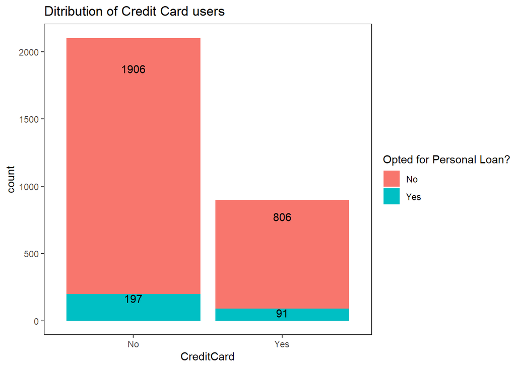

```r
ggplot(train, aes(x=CreditCard, fill=Personal.Loan)) + geom_bar() + ggtitle('Ditribution of Credit Card users') + theme_test() + scale_x_discrete(labels=c("No", "Yes")) +scale_fill_discrete(name = "Opted for Personal Loan?", labels = c("No", "Yes")) + geom_text(aes(label=..count..),stat="count", vjust=1)
```

```r
as.data.frame(table(train[,c('Personal.Loan','Online')]))
```

| Personal.Loan | Online | Freq |
| --- | --- | --- |
| 0 | 0 | 1083 |
| 1 | 0 | 116 |
| 0 | 1 | 1629 |
| 1 | 1 | 172 |

[figure not shown]

```r
ggplot(train, aes(x=Online, fill=Personal.Loan)) + geom_bar() + ggtitle('Ditribution of Credit Card users') + theme_test() + scale_x_discrete(labels=c("No", "Yes")) +scale_fill_discrete(name = "Opted for Personal Loan?", labels = c("No", "Yes"))+ geom_text(aes(label=..count..),stat="count", vjust=1)
```

> D. Compute the following quantities [P(A | B) means “the probability of A given B”]: i. P(CC = 1 | Loan = 1) (the proportion of credit card holders among the loan acceptors) ii. P(Online = 1 | Loan = 1) iii. P(Loan = 1) (the proportion of loan acceptors) iv. P(CC = 1 | Loan = 0) v. P(Online = 1 | Loan = 0) vi. P(Loan = 0)

```r
as.data.frame(table(train[,c(14,10)]))
```

| CreditCard | Personal.Loan | Freq |
| --- | --- | --- |
| 0 | 0 | 1906 |
| 1 | 0 | 806 |
| 0 | 1 | 197 |
| 1 | 1 | 91 |

```r
as.data.frame(table(train[,c(13,10)]))
```

| Online | Personal.Loan | Freq |
| --- | --- | --- |
| 0 | 0 | 1083 |
| 1 | 0 | 1629 |
| 0 | 1 | 116 |
| 1 | 1 | 172 |

```r
as.data.frame(table(train[,c(10)]))
```

| Var1 | Freq |
| --- | --- |
| 0 | 2712 |
| 1 | 288 |

> P(Cc|Pl) = 91/(91+197) = 0.31597 P(Ol|Pl) = 172/(172+116) = 0.59722 P(Pl) = 288/(288+2712) = 0.09600 P(Cc|Pl’)= 806/(806+1906) = 0.29719 P(Ol|Pl’)= 1629/(1629+1083)= 0.60066 P(Pl’) = 2712/(2712+288) = 0.90400

> E. Use the quantities computed above to compute the naive Bayes probability P(Loan = 1 | CC = 1, Online = 1).

```r
(0.31597*0.59722*0.09600) / ((0.31597*0.59722*0.09600) + (0.29719*0.60066*0.90400))
```

```
## [1] 0.1009286
```

> F. Compare this value with the one obtained from the pivot table in (B). Which is a more accurate estimate?

> G. Which of the entries in this table are needed for computing P(Loan = 1 | CC = 1, Online = 1)? Run naive Bayes on the data. Examine the model output on training data, and find the entry that corresponds to P(Loan = 1 | CC = 1, Online = 1). Compare this to the number you obtained in (E).

```r
library('e1071')
train = train[,c(10,13:14)]
test = test[,c(10,13:14)]
naivebayes = naiveBayes(Personal.Loan~.,data=train)
naivebayes
```

```
##
## Naive Bayes Classifier for Discrete Predictors
##
## Call:
## naiveBayes.default(x = X, y = Y, laplace = laplace)
##
## A-priori probabilities:
## Y
##     0     1
## 0.904 0.096
##
## Conditional probabilities:
##    Online
## Y           0         1
##   0 0.3993363 0.6006637
##   1 0.4027778 0.5972222
##
##    CreditCard
## Y           0         1
##   0 0.7028024 0.2971976
##   1 0.6840278 0.3159722
```

```r
(0.3159)*(0.5972)*(0.096)/((0.3159)*(0.5972)*(0.096) + (0.2971)*(0.6006)*(0.904))
```

```
## [1] 0.100942
```

> > The naive bayes is the exact same output we retrieved in the previous methods. (0.3159)*(0.5972)*(0.096)/((0.3159)*(0.5972)*(0.096) + (0.2971)*(0.6006)*(0.904) = 0.100942 which is almost the same response provided as above.